# EcoTriplet - CTD match, calibration and scattering correction

### Code version history

2020 Apr 07: Now includes matching full list of CTD parameters.  
2020 Apr 07: Final values are now being corrected for seawater scattering.  
2020 Apr 11: Seawater scattering - Conversion of depth in to pressure based on *EcoPuck_processing_7*  
2020 Apr 27: Dark Counts based on *EcoPuck_processing_9*  
2020 Apr 27: Chl calibration based on *EcoPuck_processing_8*  
2020 Apr 27: Remove 50 Hz interference

# EcoTriplet file processing 2: Match of Seabird CTD data, calibration and scattering correction

The EcoTriplet does not record depth. Depth information was recorded by the deck CTD unit and needs to be matched to the EcoTriplet data using time stamps. There was an unexpected time difference between recorded CTD and EcoTriplet data (potentially up to 12 seconds difference), and the two cannot be matched using the timestamp at face value. Instead, I initially match pressure roughly using the time stamp. I then use the correlations between fluorescence and turbidity (700 nm) from the SBE CTD vs the fluorescence and backscatter (700 nm) from the EcoTriplet to determine the likely time delay. To avoid including data collected out-of-water, I only use data associated with the provisional depth of >10 m.

Note, the clock on the EcoTriplet seems to have run faster, so the EcoTriplet time is AHEAD of the CTD unit.

```r
  # CTD measurements are made every second starting with the first measurement at 'start time'.
  # Function to determine start time
  start_time <- function(x){ # ctd.file.lines
    ctd.start_time.line <- x[grepl("start_time",x)]
    ctd.start_time.1st <- gsub("[# ].* = ","",ctd.start_time.line)
    ctd.start_time.2nd <- gsub(" \\[.*","",ctd.start_time.1st)
    ctd.start_time <- strptime(ctd.start_time.2nd, format="%b %d %Y %H:%M:%S", tz="UTC")
    return(ctd.start_time)
  }

  '%!in%' <- function(x,y)!('%in%'(x,y))
```

```r
  # Change working directory
  setwd("C:/Users/slcg/Dropbox/SOLSTICE/EK188/")

  # List files
  file_list <- dir("EcoPuck/DATA/clean/")[grep(".csv", dir("EcoPuck/DATA/clean/"))]
  file_list <- file_list[grepl("post",file_list)==FALSE]

  # Prepare outer loop
  profile.datetime  <- vector()
  delay.t           <- vector()
  delay.f           <- vector()
  r2.t              <- vector()
  r2.f              <- vector()
  profile.cast      <- vector()

  # Loop through each file
  for (i in 1:length(file_list)) {

    # --- File names ---
    cast          <- gsub("[a-zA-Z_.]","",file_list[i])
    filename_eco  <- paste("EcoPuck/DATA/clean/EcoPuck_",cast,".csv",sep="")
    filename_ctd  <- paste("CTD_SBE/CTD_",cast,"Sari.cnv",sep="")

    # --- Load EcoPuck data ---
    eco           <- read.csv(filename_eco, header=T)
    colnames(eco) <- c("Date","Time","Freq1","F532","Freq2","F700","Freq3","F695","Temp.counts")
    eco$Datetime  <- strptime(paste(eco$Date, eco$Time, sep=" "), format="%m/%d/%y %H:%M:%S", tz="GMT")
    eco$DTnum     <- as.numeric(eco$Datetime)

    # --- Load CTD data ---
    ctd.file_lines        <- readLines(filename_ctd)
    ctd.comment_lastline  <- which(ctd.file_lines[1:300]=="*END*")
    ctd.start_time        <- start_time(ctd.file_lines)

    ctd                   <- read.table(filename_ctd, skip = ctd.comment_lastline, fill=T)
    vars                  <- gsub("\\# .* \\= ","",ctd.file_lines[grep("\\# name", ctd.file_lines)])
    colnames(ctd)         <- gsub("\\:.*","",vars)

    # --- Measurements are made every second ---
    ctd$Time_elapsed  <- (1:nrow(ctd))-1
    ctd$Time          <- ctd.start_time+ctd$Time_elapsed
    ctd$Datetime      <- strptime(ctd$Time, format="%Y-%m-%d %H:%M:%S", tz="GMT")
    ctd$DTnum         <- as.numeric(ctd$Datetime)

    # --- Column names ---
    table_cols <- data.frame(
      "Column"=c(1:11),
      "Variable"=vars
    )

    # -----------------------------------
    # --- Loop to determine likely time delay
    # -----------------------------------

    # I first match the pressure roughly to allow me to ignore on-deck measurements
    eco$Depth_rough <- ctd$depSM[match(eco$DTnum, ctd$DTnum)]

    # If no match, move to next profile
    if (all(is.na(eco$Depth_rough))) {
      print(paste("No time match for cast:", cast, sep=" "))
      next
    }

    # If too shallow
    if (min(eco$Depth_rough<10, na.rm=T)) {
      print(paste("Cast too shallow (<10 m):", cast, sep=" "))
      next
    }

    # Prepare inner loop
    par(mfrow=c(2,3))
    r2.turb       <- vector()
    r2.fluo       <- vector()
    delay         <- vector()
    counter       <- 1

    # Loop through each potential time delay (in seconds from 0 to 11 seconds)
    for (d in 0:11) {

      # Set time delay
      time.delay          <- d

      # Match CTD and EcoTriplet data
      eco[,"turbWETntu0"] <- ctd[,"turbWETntu0"][match(eco$DTnum-time.delay, ctd$DTnum)]
      eco[,"flECO.AFL"]   <- ctd[,"flECO-AFL"][match(eco$DTnum-time.delay, ctd$DTnum)]

      # Linear regressions for backscatter and fluorescence
      lm.t              <- lm(F700 ~ turbWETntu0, dat=eco[eco$Depth_rough>10,])
      lm.f              <- lm(F695 ~ flECO.AFL, dat=eco[eco$Depth_rough>10,])

      #plot(F700 ~ turbWETntu0, dat=eco[eco$Depth_rough>10,], main=paste("Time delay: ",i,sep="")); abline(lm.t, col=2)
      #plot(F695 ~ flECO.AFL, dat=eco[eco$Depth_rough>10,], main=paste("Time delay: ",i,sep="")); abline(lm.f, col=2)

      r2.turb[counter]    <- summary(lm.t)$adj.r.squared
      r2.fluo[counter]    <- summary(lm.f)$adj.r.squared
      delay[counter]      <- d
      counter             <- counter+1
    }

    # The likely time delay was determined based on the highest R-squared value.
    k <- as.numeric(as.character(cast))

    profile.datetime[k] <- eco$DTnum[1]
    profile.cast[k]     <- cast
    delay.t[k]          <- delay[which(r2.turb==max(r2.turb))]
    delay.f[k]          <- delay[which(r2.fluo==max(r2.fluo))]
    r2.t[k]             <- max(r2.turb)
    r2.f[k]             <- max(r2.fluo)

    # Time delay table
    # table_delay <- t(data.frame(
    #   "Delay in seconds"=as.character(delay),
    #   "R-squared Turbidity"=round(r2.turb,2),
    #   "R-squared Fluorescence"=round(r2.fluo,2)
    #   ))
  }
```

```
## [1] "No time match for cast: 053"
## [1] "Cast too shallow (<10 m): 055"
## [1] "Cast too shallow (<10 m): 056"
```

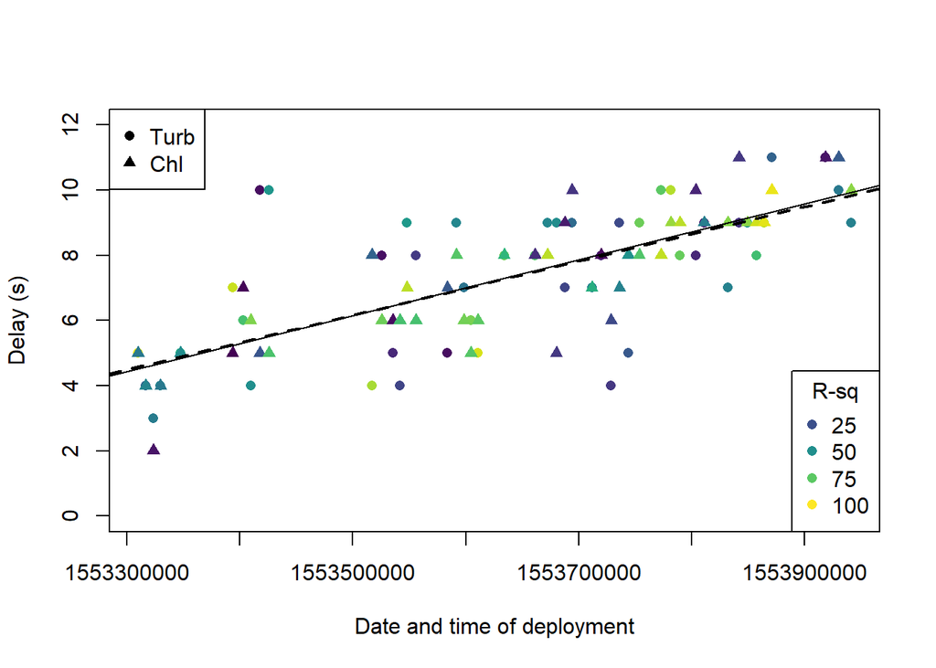

```r
  table_analysis <- data.frame(
    "Profile" = profile.cast,
    "Datetime" = profile.datetime,
    "Delay (turb)" = delay.t,
    "R-squared Turbidity"=round(r2.t,2),
    "Delay (fluo)" = delay.f,
    "R-squared Fluorescence"=round(r2.f,2)
  )

  # Plot best delay against time
  par(mfrow=c(1,1))
  plot(table_analysis$Delay..turb. ~ table_analysis$Datetime, col=viridis::viridis(100)[round(table_analysis$R.squared.Turbidity*100)], pch=16,
    ylab="Delay (s)", xlab="Date and time of deployment", ylim=c(0,12))
  points(table_analysis$Delay..fluo. ~ table_analysis$Datetime, col=viridis::viridis(100)[round(table_analysis$R.squared.Fluorescence*100)], pch=17)

  legend("topleft", col=1, pch=c(16,17), legend=c("Turb","Chl"))
  legend("bottomright", pch=16, col=viridis::viridis(100)[c(25,50,75,100)], legend=c(25,50,75,100), title="R-sq")

  DT.mod    <- c(table_analysis$Datetime,table_analysis$Datetime)
  Delay.mod <- c(table_analysis$Delay..turb.,table_analysis$Delay..fluo.)
  Weights   <- c(table_analysis$R.squared.Turbidity,table_analysis$R.squared.Fluorescence)

  lm3       <- lm(Delay.mod ~ DT.mod)
  lm3w      <- lm(Delay.mod ~ DT.mod, weights=Weights)

  abline(lm3, lty=1)
  abline(lm3w, lty=2, lwd=2)
```

```r
  print(summary(lm3w))
```

```
##
## Call:
## lm(formula = Delay.mod ~ DT.mod, weights = Weights)
##
## Weighted Residuals:
##     Min      1Q  Median      3Q     Max
## -2.1485 -0.4881  0.0078  0.4481  3.2451
##
## Coefficients:
##               Estimate Std. Error t value Pr(>|t|)
## (Intercept) -1.294e+04  1.102e+03  -11.75   <2e-16 ***
## DT.mod       8.335e-06  7.090e-07   11.76   <2e-16 ***
## ---
## Signif. codes:  0 '***' 0.001 '**' 0.01 '*' 0.05 '.' 0.1 ' ' 1
##
## Residual standard error: 0.8604 on 92 degrees of freedom
##   (14 observations deleted due to missingness)
## Multiple R-squared:  0.6004, Adjusted R-squared:  0.596
## F-statistic: 138.2 on 1 and 92 DF,  p-value: < 2.2e-16
```

```r
  print(nobs(lm3w))
```

```
## [1] 94
```

## Matching

I will use the weighted linear regression (weighted based on R2) to estimate the time delay of each profile and match the CTD pressure data. All parameters from the CTD unit are added to the EcoTriplet data.

# Calibration and seawater scattering correction

## Calibrations

S/N: BB2FLWB-1633

Date: 9/15/2017

- CHL (ug/L)= Scale Factor x (Output-Dark counts)
- *beta*(*theta*<sub>c</sub>) m<sup>-1</sup>sr<sup>-1</sup> = Scale Factor x (Output-Dark counts)

| _ | ECO Chlorophyll Fluorometer | Scattering meter at 700 nm | Scattering meter at 532 nm |
| --- | --- | --- | --- |
| Scale Factor - factory (SFf) | 0.0305 ug/l/count | 3.004E-06 (m-1sr-1)/counts | 6.974E-06 (m-1sr-1)/counts |
| Scale Factor - measured (SFm) | 0.0626 ug/l/count | N/A | N/A |
| Maximum output | 4130 | 4130 | 4130 |
| Dark Counts (factory) | 53 counts | 52 counts | 53 counts |
| Dark Counts (deep casts) | 47 ± 5 counts | 62 ± 6 counts | 27 ± 5 counts |
| Resolution | 1.2 counts | 1.3 counts 3.94E-06 (m-1sr-1) | 1.3 counts 8.77E-06 (m-1sr-1) |
| Ambient temperature during characterization | 21.5 oC | N/A | N/A |

### Factory calibration

EcoTriplet data will be converted from counts to volume scattering ($\beta$<sub>c</sub>) using the factory-provided calibrations (Table 1) and Equation 1.

1. $\beta$<sub>c</sub> = Scale Factor x (Output-Dark counts)

### Seawater correction

As $\beta$<sub>c</sub> is the total backscattering signal (in m<sup>-1</sup>sr<sup>-1</sup> ), it is the sum of backscattering from particulates ($\beta$<sub>bp</sub>) and seawater ($\beta$<sub>bsw</sub>). Backscattering of pure seawater ($\beta$<sub>bsw</sub>) is dependent on temperature, salinity and pressure, and can be calculated following the euquations by Zhang et al. (2009). These equations also considers the wavelength ($\lambda$) and the angle of the sensor ($\theta$), and the depolarization ratio ($\delta$ = 0.039). The angle of the EcoTriplet is 124<sup>$\circ$</sup> (Sullivan et al. 2013).

I have converted their matlab script into R as function (‘antics::betasw_HZP2019()’).

2. $\beta$<sub>bp</sub> = $\beta$<sub>c</sub> - $\beta$<sub>bsw</sub>($\lambda$, $\theta$, T, S, z, $\delta$)

Finally, $\beta$<sub>bp</sub> is corrected using the particulate backscattering coefficient ($\chi$ = 1.077; from Wetlabs) to convert 1 angle $\beta$<sub>bp</sub> to all angles.

3. b<sub>bp</sub> = 2 $\pi$ $\chi$ $\beta$<sub>bp</sub>

I truncate the data to exclude ‘out-of-water’ readings, and save everything as a new file.

### Notes

- The salinity has not been calibrated yet. However, salinity of uncalibrated CTD unit seemed to match well with the calibrated glider data, and is - at most - out by 0.1 psu units. This potential discrepancy will likely have a negligible effect on the final results.
- I do not have pressure, so I am estimating pressure following the equation determined in *EcoPuck_processing_7*:

Press (dbar) = -0.005006611 + 1.007483257 Depth (m)

An alternative way would have been to use the equation $P = \rho g z / 10000$, where $\rho$ is appoximate density in kg/m<sup>3</sup> (based on mean salinity during the profile), $g$ is the gravitational constant (9.8 m/s<sup>2</sup>), $z$ is depth (in m), and 10000 the conversion factor from Pascal to dbar.

```r
  # Scattering parameter
  lambda_700  <- 700    # wavelength light in air
  lambda_532  <- 532    # wavelength light in air
  theta       <- 124    # angle
  delta       <- 0.039  # Farinato and Roswell (1976) - dipolarization ratio
  Xi          <- 1.077  # factor to convert 1 angle bbp to all angles (from wetlabs)

  # Change working directory
  setwd("C:/Users/slcg/Dropbox/SOLSTICE/EK188/")

  # make empty data frame for compiled data
  dat <- vector()

  # Loop through each file
  for (i in 1:length(file_list)) {

    # --- File names ---
    cast          <- gsub("[a-zA-Z_.]","",file_list[i])
    filename_eco  <- paste("EcoPuck/DATA/clean/EcoPuck_",cast,".csv",sep="")
    filename_ctd  <- paste("CTD_SBE/CTD_",cast,"Sari.cnv",sep="")

    # --- Load EcoPuck data ---
    eco           <- read.csv(filename_eco, header=T)
    colnames(eco) <- c("Date","Time","Freq1","F532","Freq2","F700","Freq3","F695","Temp.counts")
    eco$Datetime  <- strptime(paste(eco$Date, eco$Time, sep=" "), format="%m/%d/%y %H:%M:%S", tz="GMT")
    eco$DTnum     <- as.numeric(eco$Datetime)

    # --- Load CTD data ---
    ctd.file_lines        <- readLines(filename_ctd)
    ctd.comment_lastline  <- which(ctd.file_lines[1:300]=="*END*")
    ctd.start_time        <- start_time(ctd.file_lines)

    ctd                   <- read.table(filename_ctd, skip = ctd.comment_lastline, fill=T)
    vars                  <- gsub("\\# .* \\= ","",ctd.file_lines[grep("\\# name", ctd.file_lines)])
    colnames(ctd)         <- gsub("\\:.*","",vars)

    # --- Measurements are made every second ---
    ctd$Time_elapsed  <- (1:nrow(ctd))-1
    ctd$Time          <- ctd.start_time+ctd$Time_elapsed
    ctd$Datetime      <- strptime(ctd$Time, format="%Y-%m-%d %H:%M:%S", tz="GMT")
    ctd$DTnum         <- as.numeric(ctd$Datetime)

    # Predict time delay based on regression model
    time.delay        <- round(predict(lm3w, newdata=list(DT.mod = eco$DTnum[1])))

    # check if there is a match
    if (all(is.na(match(eco$DTnum-time.delay, ctd$DTnum)))) {
      print(paste("No match between CTD and EcoTriplet: Cast ", cast, sep=""))
      next
    }

    # Match CTD data
    for (k in names(ctd[1:10])) eco[,k]   <- ctd[,k][match(eco$DTnum-time.delay, ctd$DTnum)]

    # Rename depth
    eco$Depth <- eco$depSM

    # Remove missing values
    eco.trunc <- eco[is.na(eco$Depth)==FALSE,]

    # -----------------------------------
    # --- Convert counts into units
    # -----------------------------------

    # Using the supplied calibration sheets, convert counts into total backscattering (bc).
    eco.trunc$bc_532        <- 6.974e-06 * (eco.trunc$F532 - 27) # m-1 sr-1
    eco.trunc$bc_700        <- 3.004e-06 * (eco.trunc$F700 - 62) # m-1 sr-1
    eco.trunc$Chl.ugL       <- 0.0626    * (eco.trunc$F695 - 47) # ug/l

    # Calculate seawater backscattering (bsw)
    eco.trunc$bsw_532       <- antics::betasw_HZP2019(lambda = lambda_532,
                                              theta = theta,
                                              Tc = eco.trunc$t090C,
                                              SA = eco.trunc$sal00 * 1.0047,
                                              p = -0.005006611 + 1.007483257 * eco.trunc$depSM,
                                              delta = delta)$betasw

    eco.trunc$bsw_700       <- antics::betasw_HZP2019(lambda = lambda_700,
                                              theta = theta,
                                              Tc = eco.trunc$t090C,
                                              SA = eco.trunc$sal00 * 1.0047,
                                              p = -0.005006611 + 1.007483257 * eco.trunc$depSM,
                                              delta = delta)$betasw

    # Calculate backscattering due to particulates (bbp)
    eco.trunc$bbp_532       <- eco.trunc$bc_532 - eco.trunc$bsw_532
    eco.trunc$bbp_700       <- eco.trunc$bc_700 - eco.trunc$bsw_700

    # Correct using particulate backscattering coefficient
    eco.trunc$B532.msr      <- 2 * pi * Xi * eco.trunc$bbp_532 # m-1 sr-1
    eco.trunc$B700.msr      <- 2 * pi * Xi * eco.trunc$bbp_700 # m-1 sr-1

    # Save output
    write.csv(eco.trunc[, c("Date","Time","Depth",
                            "F532", "F700", "F695",
                            "B532.msr","B700.msr","Chl.ugL",
                            "latitude", "longitude", "t090C", "sal00",
                            "bsw_532", "bsw_700")],
      paste("EcoPuck/DATA/work/EcoPuck_", cast, "_work.csv", sep=""),
      row.names=FALSE)

    # add name to data frame
    eco.trunc$Profile <- paste("EcoPuck_", cast, sep="")

    # add profile to master data frame
    dat <- rbind(dat, eco.trunc)
  }
```

```
## [1] "No match between CTD and EcoTriplet: Cast 053"
```

## Negative values and 50 Hz interference

The data showed interference of 50 Hz as indicated by an unusually frequent occurance of 50 *counts*. The 50 Hz interference is most likely caused by the ship’s mains (South African electricity frequency: 50 Hz) conducting through the CTD frame that the EcoTriplet was mounted on.

I remove all 50 Hz readings (i.e. remove the interference signal). As we have high-resolution data (10 Hz sampling) and final numbers are averaged and binned, this should not pose a problem in the data analysis.

```r
  library(antics)

  # histogrammes of raw-counts data
  par(mfrow=c(2,2))
  # 532 nm
  h532  <- aggregate(dat$F532[dat$F532 < 100], by=list(dat$F532[dat$F532 < 100]), length)
  COL   <- rep(d3[1], length(h532$Group.1)); COL[h532$Group.1%in%50] <- d3[2]
  barplot(h532$x, names.arg=h532$Group.1, col=COL, main="532 nm")

  # 700 nm
  h700  <- aggregate(dat$F700[dat$F700 < 100], by=list(dat$F700[dat$F700 < 100]), length)
  COL   <- rep(d3[1], length(h700$Group.1)); COL[h700$Group.1%in%50] <- d3[2]
  barplot(h700$x, names.arg=h700$Group.1, col=COL, main="700 nm")

  # 695 nm
  h695  <- aggregate(dat$F695[dat$F695 < 100], by=list(dat$F695[dat$F695 < 100]), length)
  COL   <- rep(d3[1], length(h695$Group.1)); COL[h695$Group.1%in%50] <- d3[2]
  barplot(h695$x, names.arg=h695$Group.1, col=COL, main="695 nm")

  # percent of data
  length(dat$F532[dat$F532 %in% 50])/nrow(dat)
```

```
## [1] 0.0317618
```

```r
  length(dat$F700[dat$F700 %in% 50])/nrow(dat)
```

```
## [1] 0.00509082
```

```r
  length(dat$F695[dat$F695 %in% 50])/nrow(dat)
```

```
## [1] 0.07257488
```

```r
  # Remove interference signal
  dat <- dat[(dat$F532 == 50 | dat$F700 == 50 | dat$F695 == 50)==FALSE,]
```

[figure not shown]

```r
  # Save file for future
  setwd("C:/Users/slcg/Dropbox/SOLSTICE/EK188/")
  write.csv(dat,  "EK188_EcoTriplet_all_casts.csv", row.names=F)
```

## References

J. M. Sullivan, M. S. Twardowski, J. Ronald, V. Zaneveld, C. C. Moore, in Light Scattering Reviews 7, A. A. Kokhanovsky, Ed. (Springer, 2013), pp. 189–224. [ONLINE](https://link.springer.com/chapter/10.1007%2F978-3-642-21907-8_6)

X. Zhang, L. Hu, M. X. He, Scattering by pure seawater: Effect of salinity. Opt. Express 17, 5698–5710 (2009). doi:10.1364/OE.17.005698 [ONLINE](https://www.osapublishing.org/oe/abstract.cfm?uri=oe-17-7-5698)